# Risk Factor Analysis

## Outcome Variable

**Outcome Variable:** wast_rec90d

## Predictor Variables

**Intervention Variable:** parity

**Adjustment Set:**

unadjusted

## Stratifying Variables

The analysis was stratified on these variable(s):

- agecat
- studyid
- country

## Data Summary

| agecat | studyid | country | parity | wast_rec90d | n_cell | n |
| --- | --- | --- | --- | --- | --- | --- |
| 0-24 months | COHORTS | GUATEMALA | 1 | 0 | 26 | 380 |
| 0-24 months | COHORTS | GUATEMALA | 1 | 1 | 23 | 380 |
| 0-24 months | COHORTS | GUATEMALA | 2 | 0 | 27 | 380 |
| 0-24 months | COHORTS | GUATEMALA | 2 | 1 | 32 | 380 |
| 0-24 months | COHORTS | GUATEMALA | 3+ | 0 | 159 | 380 |
| 0-24 months | COHORTS | GUATEMALA | 3+ | 1 | 113 | 380 |
| 0-24 months | COHORTS | INDIA | 1 | 0 | 188 | 1708 |
| 0-24 months | COHORTS | INDIA | 1 | 1 | 82 | 1708 |
| 0-24 months | COHORTS | INDIA | 2 | 0 | 296 | 1708 |
| 0-24 months | COHORTS | INDIA | 2 | 1 | 98 | 1708 |
| 0-24 months | COHORTS | INDIA | 3+ | 0 | 830 | 1708 |
| 0-24 months | COHORTS | INDIA | 3+ | 1 | 214 | 1708 |
| 0-24 months | COHORTS | PHILIPPINES | 1 | 0 | 140 | 1689 |
| 0-24 months | COHORTS | PHILIPPINES | 1 | 1 | 241 | 1689 |
| 0-24 months | COHORTS | PHILIPPINES | 2 | 0 | 133 | 1689 |
| 0-24 months | COHORTS | PHILIPPINES | 2 | 1 | 226 | 1689 |
| 0-24 months | COHORTS | PHILIPPINES | 3+ | 0 | 391 | 1689 |
| 0-24 months | COHORTS | PHILIPPINES | 3+ | 1 | 558 | 1689 |
| 0-24 months | GMS-Nepal | NEPAL | 1 | 0 | 79 | 643 |
| 0-24 months | GMS-Nepal | NEPAL | 1 | 1 | 101 | 643 |
| 0-24 months | GMS-Nepal | NEPAL | 2 | 0 | 72 | 643 |
| 0-24 months | GMS-Nepal | NEPAL | 2 | 1 | 86 | 643 |
| 0-24 months | GMS-Nepal | NEPAL | 3+ | 0 | 145 | 643 |
| 0-24 months | GMS-Nepal | NEPAL | 3+ | 1 | 160 | 643 |
| 0-24 months | Keneba | GAMBIA | 1 | 0 | 46 | 1438 |
| 0-24 months | Keneba | GAMBIA | 1 | 1 | 120 | 1438 |
| 0-24 months | Keneba | GAMBIA | 2 | 0 | 44 | 1438 |
| 0-24 months | Keneba | GAMBIA | 2 | 1 | 95 | 1438 |
| 0-24 months | Keneba | GAMBIA | 3+ | 0 | 436 | 1438 |
| 0-24 months | Keneba | GAMBIA | 3+ | 1 | 697 | 1438 |

[output cut: 150 more lines]

The following strata were considered:

- agecat: 0-24 months, studyid: COHORTS, country: GUATEMALA
- agecat: 0-24 months, studyid: COHORTS, country: INDIA
- agecat: 0-24 months, studyid: COHORTS, country: PHILIPPINES
- agecat: 0-24 months, studyid: GMS-Nepal, country: NEPAL
- agecat: 0-24 months, studyid: Keneba, country: GAMBIA
- agecat: 0-24 months, studyid: PROVIDE, country: BANGLADESH
- agecat: 0-24 months, studyid: SAS-CompFeed, country: INDIA
- agecat: 0-24 months, studyid: SAS-FoodSuppl, country: INDIA
- agecat: 0-24 months, studyid: TanzaniaChild2, country: TANZANIA, UNITED REPUBLIC OF
- agecat: 0-24 months, studyid: ZVITAMBO, country: ZIMBABWE
- agecat: 0-6 months, studyid: COHORTS, country: GUATEMALA
- agecat: 0-6 months, studyid: COHORTS, country: INDIA
- agecat: 0-6 months, studyid: COHORTS, country: PHILIPPINES
- agecat: 0-6 months, studyid: GMS-Nepal, country: NEPAL
- agecat: 0-6 months, studyid: Keneba, country: GAMBIA
- agecat: 0-6 months, studyid: PROVIDE, country: BANGLADESH
- agecat: 0-6 months, studyid: SAS-CompFeed, country: INDIA
- agecat: 0-6 months, studyid: SAS-FoodSuppl, country: INDIA
- agecat: 0-6 months, studyid: TanzaniaChild2, country: TANZANIA, UNITED REPUBLIC OF
- agecat: 0-6 months, studyid: ZVITAMBO, country: ZIMBABWE
- agecat: 6-24 months, studyid: COHORTS, country: GUATEMALA
- agecat: 6-24 months, studyid: COHORTS, country: INDIA
- agecat: 6-24 months, studyid: COHORTS, country: PHILIPPINES
- agecat: 6-24 months, studyid: GMS-Nepal, country: NEPAL
- agecat: 6-24 months, studyid: Keneba, country: GAMBIA
- agecat: 6-24 months, studyid: PROVIDE, country: BANGLADESH
- agecat: 6-24 months, studyid: SAS-CompFeed, country: INDIA
- agecat: 6-24 months, studyid: SAS-FoodSuppl, country: INDIA
- agecat: 6-24 months, studyid: TanzaniaChild2, country: TANZANIA, UNITED REPUBLIC OF
- agecat: 6-24 months, studyid: ZVITAMBO, country: ZIMBABWE

### Dropped Strata

Some strata were dropped due to rare outcomes:

- agecat: 0-24 months, studyid: SAS-FoodSuppl, country: INDIA
- agecat: 0-6 months, studyid: SAS-FoodSuppl, country: INDIA
- agecat: 6-24 months, studyid: COHORTS, country: GUATEMALA
- agecat: 6-24 months, studyid: COHORTS, country: INDIA
- agecat: 6-24 months, studyid: SAS-FoodSuppl, country: INDIA

## Methods Detail

We’re interested in the causal parameters $E[Y_a]$ for all values of $a \in \mathcal{A}$. These parameters represent the mean outcome if, possibly contrary to fact, we intervened to set all units to have $A=a$. Under the randomization and positivity assumptions, these are identified by the statistical parameters $\psi_a=E_W[E_{Y|A,W}(Y|A=a,W)]$. In addition, we’re interested in the mean of $Y$, $E[Y]$ under no intervention (the observed mean). We will estimate these parameters by using SuperLearner to fit the relevant likelihood factors – $E_{Y|A,W}(Y|A=a,W)$ and $p(A=a|W)$, and then updating our likelihood fit using a joint TMLE.

For unadjusted analyses ($W=\{\}$), initial likelihoods were estimated using Lrnr_glm to estimate the simple $E(Y|A)$ and Lrnr_mean to estimate $p(A)$. For adjusted analyses, a small library containing Lrnr_glmnet, Lrnr_xgboost, and Lrnr_mean was used.

Having estimated these parameters, we will then use the delta method to estimate relative risks and attributable risks relative to a prespecified baseline level of $A$.

# Results Detail

## Results Plots

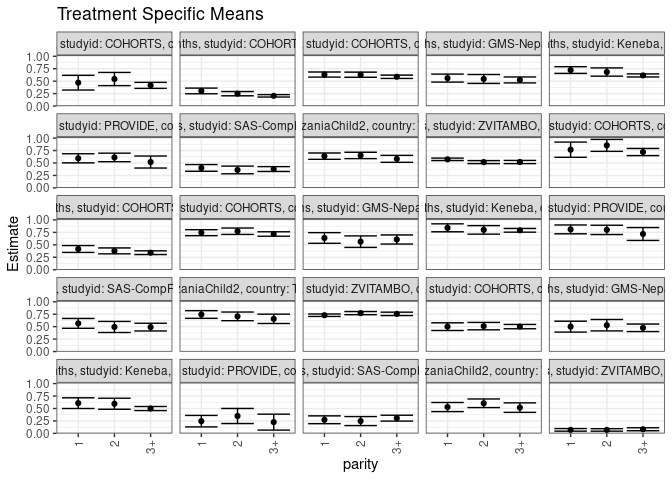

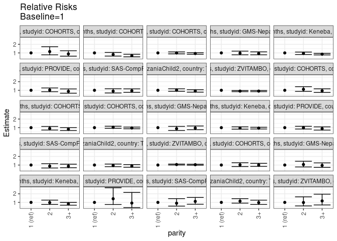

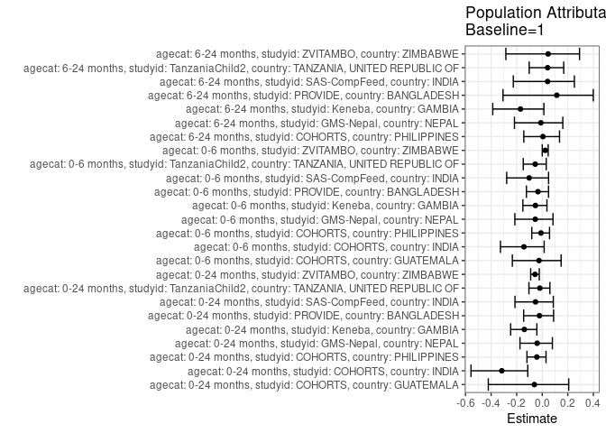

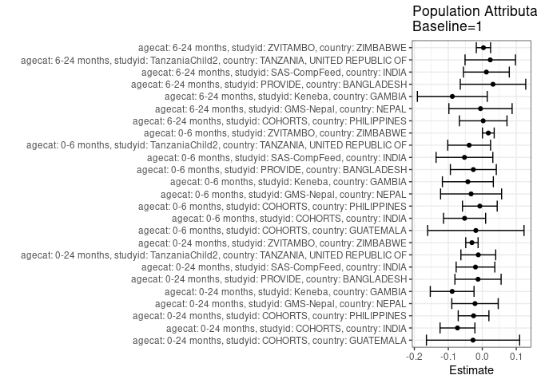

## Results Table

### Parameter: TSM

| agecat | studyid | country | intervention_level | baseline_level | estimate | ci_lower | ci_upper |
| --- | --- | --- | --- | --- | --- | --- | --- |
| 0-24 months | COHORTS | GUATEMALA | 1 | NA | 0.4693878 | 0.3218938 | 0.6168817 |
| 0-24 months | COHORTS | GUATEMALA | 2 | NA | 0.5423729 | 0.4099003 | 0.6748455 |
| 0-24 months | COHORTS | GUATEMALA | 3+ | NA | 0.4154412 | 0.3551125 | 0.4757698 |
| 0-24 months | COHORTS | INDIA | 1 | NA | 0.3037037 | 0.2466236 | 0.3607838 |
| 0-24 months | COHORTS | INDIA | 2 | NA | 0.2487310 | 0.2058243 | 0.2916376 |
| 0-24 months | COHORTS | INDIA | 3+ | NA | 0.2049808 | 0.1806925 | 0.2292692 |
| 0-24 months | COHORTS | PHILIPPINES | 1 | NA | 0.6325459 | 0.5812627 | 0.6838292 |
| 0-24 months | COHORTS | PHILIPPINES | 2 | NA | 0.6295265 | 0.5778482 | 0.6812047 |
| 0-24 months | COHORTS | PHILIPPINES | 3+ | NA | 0.5879874 | 0.5549622 | 0.6210125 |
| 0-24 months | GMS-Nepal | NEPAL | 1 | NA | 0.5611111 | 0.4805261 | 0.6416961 |
| 0-24 months | GMS-Nepal | NEPAL | 2 | NA | 0.5443038 | 0.4548151 | 0.6337925 |
| 0-24 months | GMS-Nepal | NEPAL | 3+ | NA | 0.5245902 | 0.4650747 | 0.5841056 |
| 0-24 months | Keneba | GAMBIA | 1 | NA | 0.7228916 | 0.6558480 | 0.7899351 |
| 0-24 months | Keneba | GAMBIA | 2 | NA | 0.6834532 | 0.6003324 | 0.7665741 |
| 0-24 months | Keneba | GAMBIA | 3+ | NA | 0.6151809 | 0.5844010 | 0.6459608 |
| 0-24 months | PROVIDE | BANGLADESH | 1 | NA | 0.5937500 | 0.5022685 | 0.6852315 |
| 0-24 months | PROVIDE | BANGLADESH | 2 | NA | 0.6116505 | 0.5261615 | 0.6971395 |
| 0-24 months | PROVIDE | BANGLADESH | 3+ | NA | 0.5194805 | 0.3989308 | 0.6400302 |
| 0-24 months | SAS-CompFeed | INDIA | 1 | NA | 0.4008811 | 0.3335233 | 0.4682389 |
| 0-24 months | SAS-CompFeed | INDIA | 2 | NA | 0.3604651 | 0.2836475 | 0.4372827 |
| 0-24 months | SAS-CompFeed | INDIA | 3+ | NA | 0.3783133 | 0.3297924 | 0.4268341 |
| 0-24 months | TanzaniaChild2 | TANZANIA, UNITED REPUBLIC OF | 1 | NA | 0.6370968 | 0.5736047 | 0.7005888 |
| 0-24 months | TanzaniaChild2 | TANZANIA, UNITED REPUBLIC OF | 2 | NA | 0.6512605 | 0.5873324 | 0.7151886 |
| 0-24 months | TanzaniaChild2 | TANZANIA, UNITED REPUBLIC OF | 3+ | NA | 0.5833333 | 0.5133344 | 0.6533322 |
| 0-24 months | ZVITAMBO | ZIMBABWE | 1 | NA | 0.5738110 | 0.5492976 | 0.5983244 |
| 0-24 months | ZVITAMBO | ZIMBABWE | 2 | NA | 0.5178744 | 0.4876430 | 0.5481058 |
| 0-24 months | ZVITAMBO | ZIMBABWE | 3+ | NA | 0.5192508 | 0.4871789 | 0.5513226 |
| 0-6 months | COHORTS | GUATEMALA | 1 | NA | 0.7666667 | 0.6142490 | 0.9190843 |
| 0-6 months | COHORTS | GUATEMALA | 2 | NA | 0.8529412 | 0.7330548 | 0.9728275 |
| 0-6 months | COHORTS | GUATEMALA | 3+ | NA | 0.7200000 | 0.6482985 | 0.7917015 |
| 0-6 months | COHORTS | INDIA | 1 | NA | 0.4162437 | 0.3473776 | 0.4851097 |
| 0-6 months | COHORTS | INDIA | 2 | NA | 0.3783784 | 0.3192869 | 0.4374699 |
| 0-6 months | COHORTS | INDIA | 3+ | NA | 0.3418530 | 0.3046787 | 0.3790273 |
| 0-6 months | COHORTS | PHILIPPINES | 1 | NA | 0.7439614 | 0.6839765 | 0.8039462 |
| 0-6 months | COHORTS | PHILIPPINES | 2 | NA | 0.7730061 | 0.7085362 | 0.8374760 |
| 0-6 months | COHORTS | PHILIPPINES | 3+ | NA | 0.7172775 | 0.6721142 | 0.7624408 |
| 0-6 months | GMS-Nepal | NEPAL | 1 | NA | 0.6375000 | 0.5302934 | 0.7447066 |
| 0-6 months | GMS-Nepal | NEPAL | 2 | NA | 0.5633803 | 0.4479206 | 0.6788400 |
| 0-6 months | GMS-Nepal | NEPAL | 3+ | NA | 0.6071429 | 0.5159212 | 0.6983645 |
| 0-6 months | Keneba | GAMBIA | 1 | NA | 0.8414634 | 0.7614909 | 0.9214360 |
| 0-6 months | Keneba | GAMBIA | 2 | NA | 0.8000000 | 0.7141218 | 0.8858782 |
| 0-6 months | Keneba | GAMBIA | 3+ | NA | 0.7911111 | 0.7538455 | 0.8283767 |
| 0-6 months | PROVIDE | BANGLADESH | 1 | NA | 0.8101266 | 0.7214846 | 0.8987685 |
| 0-6 months | PROVIDE | BANGLADESH | 2 | NA | 0.8000000 | 0.7063409 | 0.8936591 |
| 0-6 months | PROVIDE | BANGLADESH | 3+ | NA | 0.7173913 | 0.5880020 | 0.8467806 |
| 0-6 months | SAS-CompFeed | INDIA | 1 | NA | 0.5656566 | 0.4667621 | 0.6645510 |
| 0-6 months | SAS-CompFeed | INDIA | 2 | NA | 0.4936709 | 0.3828383 | 0.6045035 |
| 0-6 months | SAS-CompFeed | INDIA | 3+ | NA | 0.4907975 | 0.4133687 | 0.5682264 |
| 0-6 months | TanzaniaChild2 | TANZANIA, UNITED REPUBLIC OF | 1 | NA | 0.7440000 | 0.6670006 | 0.8209994 |
| 0-6 months | TanzaniaChild2 | TANZANIA, UNITED REPUBLIC OF | 2 | NA | 0.7064220 | 0.6191448 | 0.7936993 |
| 0-6 months | TanzaniaChild2 | TANZANIA, UNITED REPUBLIC OF | 3+ | NA | 0.6568627 | 0.5631121 | 0.7506134 |
| 0-6 months | ZVITAMBO | ZIMBABWE | 1 | NA | 0.7297735 | 0.7050864 | 0.7544605 |
| 0-6 months | ZVITAMBO | ZIMBABWE | 2 | NA | 0.7715582 | 0.7395778 | 0.8035387 |
| 0-6 months | ZVITAMBO | ZIMBABWE | 3+ | NA | 0.7572347 | 0.7234077 | 0.7910617 |
| 6-24 months | COHORTS | PHILIPPINES | 1 | NA | 0.5000000 | 0.4226978 | 0.5773022 |
| 6-24 months | COHORTS | PHILIPPINES | 2 | NA | 0.5102041 | 0.4359618 | 0.5844463 |
| 6-24 months | COHORTS | PHILIPPINES | 3+ | NA | 0.5008818 | 0.4572446 | 0.5445191 |
| 6-24 months | GMS-Nepal | NEPAL | 1 | NA | 0.5000000 | 0.3905532 | 0.6094468 |
| 6-24 months | GMS-Nepal | NEPAL | 2 | NA | 0.5287356 | 0.4141631 | 0.6433081 |
| 6-24 months | GMS-Nepal | NEPAL | 3+ | NA | 0.4766839 | 0.4013570 | 0.5520109 |
| 6-24 months | Keneba | GAMBIA | 1 | NA | 0.6071429 | 0.4998629 | 0.7144228 |
| 6-24 months | Keneba | GAMBIA | 2 | NA | 0.5949367 | 0.4844181 | 0.7054553 |
| 6-24 months | Keneba | GAMBIA | 3+ | NA | 0.4992679 | 0.4584119 | 0.5401240 |
| 6-24 months | PROVIDE | BANGLADESH | 1 | NA | 0.2448980 | 0.1297835 | 0.3600124 |
| 6-24 months | PROVIDE | BANGLADESH | 2 | NA | 0.3488372 | 0.1975901 | 0.5000843 |
| 6-24 months | PROVIDE | BANGLADESH | 3+ | NA | 0.2258065 | 0.0656328 | 0.3859801 |
| 6-24 months | SAS-CompFeed | INDIA | 1 | NA | 0.2734375 | 0.1951641 | 0.3517109 |
| 6-24 months | SAS-CompFeed | INDIA | 2 | NA | 0.2473118 | 0.1571231 | 0.3375005 |
| 6-24 months | SAS-CompFeed | INDIA | 3+ | NA | 0.3055556 | 0.2468560 | 0.3642552 |
| 6-24 months | TanzaniaChild2 | TANZANIA, UNITED REPUBLIC OF | 1 | NA | 0.5284553 | 0.4371428 | 0.6197678 |
| 6-24 months | TanzaniaChild2 | TANZANIA, UNITED REPUBLIC OF | 2 | NA | 0.6046512 | 0.5181147 | 0.6911876 |
| 6-24 months | TanzaniaChild2 | TANZANIA, UNITED REPUBLIC OF | 3+ | NA | 0.5175439 | 0.4219153 | 0.6131725 |
| 6-24 months | ZVITAMBO | ZIMBABWE | 1 | NA | 0.0704961 | 0.0445600 | 0.0964322 |
| 6-24 months | ZVITAMBO | ZIMBABWE | 2 | NA | 0.0695187 | 0.0448025 | 0.0942349 |
| 6-24 months | ZVITAMBO | ZIMBABWE | 3+ | NA | 0.0825959 | 0.0529376 | 0.1122542 |

### Parameter: E(Y)

| agecat | studyid | country | intervention_level | baseline_level | estimate | ci_lower | ci_upper |
| --- | --- | --- | --- | --- | --- | --- | --- |
| 0-24 months | COHORTS | GUATEMALA | NA | NA | 0.4421053 | 0.3904403 | 0.4937702 |
| 0-24 months | COHORTS | INDIA | NA | NA | 0.2306792 | 0.2105836 | 0.2507747 |
| 0-24 months | COHORTS | PHILIPPINES | NA | NA | 0.6068680 | 0.5823645 | 0.6313715 |
| 0-24 months | GMS-Nepal | NEPAL | NA | NA | 0.5396579 | 0.4973524 | 0.5819633 |
| 0-24 months | Keneba | GAMBIA | NA | NA | 0.6342142 | 0.6073589 | 0.6610695 |
| 0-24 months | PROVIDE | BANGLADESH | NA | NA | 0.5811688 | 0.5245443 | 0.6377934 |
| 0-24 months | SAS-CompFeed | INDIA | NA | NA | 0.3808354 | 0.3457640 | 0.4159068 |
| 0-24 months | TanzaniaChild2 | TANZANIA, UNITED REPUBLIC OF | NA | NA | 0.6253561 | 0.5873792 | 0.6633330 |
| 0-24 months | ZVITAMBO | ZIMBABWE | NA | NA | 0.5432918 | 0.5268968 | 0.5596869 |
| 0-6 months | COHORTS | GUATEMALA | NA | NA | 0.7476636 | 0.6894668 | 0.8058603 |
| 0-6 months | COHORTS | INDIA | NA | NA | 0.3641405 | 0.3354558 | 0.3928252 |
| 0-6 months | COHORTS | PHILIPPINES | NA | NA | 0.7367021 | 0.7051294 | 0.7682749 |
| 0-6 months | GMS-Nepal | NEPAL | NA | NA | 0.6045627 | 0.5449300 | 0.6641955 |
| 0-6 months | Keneba | GAMBIA | NA | NA | 0.7989865 | 0.7673199 | 0.8306531 |
| 0-6 months | PROVIDE | BANGLADESH | NA | NA | 0.7837838 | 0.7252863 | 0.8422812 |
| 0-6 months | SAS-CompFeed | INDIA | NA | NA | 0.5131965 | 0.4596632 | 0.5667297 |
| 0-6 months | TanzaniaChild2 | TANZANIA, UNITED REPUBLIC OF | NA | NA | 0.7053571 | 0.6558827 | 0.7548316 |
| 0-6 months | ZVITAMBO | ZIMBABWE | NA | NA | 0.7475189 | 0.7305656 | 0.7644721 |
| 6-24 months | COHORTS | PHILIPPINES | NA | NA | 0.5026681 | 0.4688378 | 0.5364984 |
| 6-24 months | GMS-Nepal | NEPAL | NA | NA | 0.4947368 | 0.4401559 | 0.5493178 |
| 6-24 months | Keneba | GAMBIA | NA | NA | 0.5189125 | 0.4826376 | 0.5551875 |
| 6-24 months | PROVIDE | BANGLADESH | NA | NA | 0.2764228 | 0.1950773 | 0.3577682 |
| 6-24 months | SAS-CompFeed | INDIA | NA | NA | 0.2854123 | 0.2436284 | 0.3271961 |
| 6-24 months | TanzaniaChild2 | TANZANIA, UNITED REPUBLIC OF | NA | NA | 0.5519126 | 0.4992021 | 0.6046230 |
| 6-24 months | ZVITAMBO | ZIMBABWE | NA | NA | 0.0739051 | 0.0584895 | 0.0893208 |

### Parameter: RR

| agecat | studyid | country | intervention_level | baseline_level | estimate | ci_lower | ci_upper |
| --- | --- | --- | --- | --- | --- | --- | --- |
| 0-24 months | COHORTS | GUATEMALA | 1 | 1 | 1.0000000 | 1.0000000 | 1.0000000 |
| 0-24 months | COHORTS | GUATEMALA | 2 | 1 | 1.1554901 | 0.7760981 | 1.7203460 |
| 0-24 months | COHORTS | GUATEMALA | 3+ | 1 | 0.8850703 | 0.6260791 | 1.2511989 |
| 0-24 months | COHORTS | INDIA | 1 | 1 | 1.0000000 | 1.0000000 | 1.0000000 |
| 0-24 months | COHORTS | INDIA | 2 | 1 | 0.8189922 | 0.6345843 | 1.0569883 |
| 0-24 months | COHORTS | INDIA | 3+ | 1 | 0.6749369 | 0.5404739 | 0.8428526 |
| 0-24 months | COHORTS | PHILIPPINES | 1 | 1 | 1.0000000 | 1.0000000 | 1.0000000 |
| 0-24 months | COHORTS | PHILIPPINES | 2 | 1 | 0.9952265 | 0.8867579 | 1.1169630 |
| 0-24 months | COHORTS | PHILIPPINES | 3+ | 1 | 0.9295568 | 0.8422341 | 1.0259330 |
| 0-24 months | GMS-Nepal | NEPAL | 1 | 1 | 1.0000000 | 1.0000000 | 1.0000000 |
| 0-24 months | GMS-Nepal | NEPAL | 2 | 1 | 0.9700464 | 0.7797680 | 1.2067563 |
| 0-24 months | GMS-Nepal | NEPAL | 3+ | 1 | 0.9349132 | 0.7784911 | 1.1227651 |
| 0-24 months | Keneba | GAMBIA | 1 | 1 | 1.0000000 | 1.0000000 | 1.0000000 |
| 0-24 months | Keneba | GAMBIA | 2 | 1 | 0.9454436 | 0.8113316 | 1.1017242 |
| 0-24 months | Keneba | GAMBIA | 3+ | 1 | 0.8510003 | 0.7658698 | 0.9455935 |
| 0-24 months | PROVIDE | BANGLADESH | 1 | 1 | 1.0000000 | 1.0000000 | 1.0000000 |
| 0-24 months | PROVIDE | BANGLADESH | 2 | 1 | 1.0301482 | 0.8363904 | 1.2687918 |
| 0-24 months | PROVIDE | BANGLADESH | 3+ | 1 | 0.8749146 | 0.6622004 | 1.1559575 |
| 0-24 months | SAS-CompFeed | INDIA | 1 | 1 | 1.0000000 | 1.0000000 | 1.0000000 |
| 0-24 months | SAS-CompFeed | INDIA | 2 | 1 | 0.8991822 | 0.6854700 | 1.1795244 |
| 0-24 months | SAS-CompFeed | INDIA | 3+ | 1 | 0.9437045 | 0.7638947 | 1.1658389 |
| 0-24 months | TanzaniaChild2 | TANZANIA, UNITED REPUBLIC OF | 1 | 1 | 1.0000000 | 1.0000000 | 1.0000000 |
| 0-24 months | TanzaniaChild2 | TANZANIA, UNITED REPUBLIC OF | 2 | 1 | 1.0222317 | 0.8887885 | 1.1757100 |
| 0-24 months | TanzaniaChild2 | TANZANIA, UNITED REPUBLIC OF | 3+ | 1 | 0.9156118 | 0.7833713 | 1.0701758 |
| 0-24 months | ZVITAMBO | ZIMBABWE | 1 | 1 | 1.0000000 | 1.0000000 | 1.0000000 |
| 0-24 months | ZVITAMBO | ZIMBABWE | 2 | 1 | 0.9025174 | 0.8395298 | 0.9702307 |
| 0-24 months | ZVITAMBO | ZIMBABWE | 3+ | 1 | 0.9049161 | 0.8394371 | 0.9755025 |
| 0-6 months | COHORTS | GUATEMALA | 1 | 1 | 1.0000000 | 1.0000000 | 1.0000000 |
| 0-6 months | COHORTS | GUATEMALA | 2 | 1 | 1.1125320 | 0.8721133 | 1.4192277 |
| 0-6 months | COHORTS | GUATEMALA | 3+ | 1 | 0.9391304 | 0.7518984 | 1.1729855 |
| 0-6 months | COHORTS | INDIA | 1 | 1 | 1.0000000 | 1.0000000 | 1.0000000 |
| 0-6 months | COHORTS | INDIA | 2 | 1 | 0.9090310 | 0.7240548 | 1.1412636 |
| 0-6 months | COHORTS | INDIA | 3+ | 1 | 0.8212811 | 0.6737649 | 1.0010949 |
| 0-6 months | COHORTS | PHILIPPINES | 1 | 1 | 1.0000000 | 1.0000000 | 1.0000000 |
| 0-6 months | COHORTS | PHILIPPINES | 2 | 1 | 1.0390407 | 0.9252364 | 1.1668429 |
| 0-6 months | COHORTS | PHILIPPINES | 3+ | 1 | 0.9641327 | 0.8703775 | 1.0679871 |
| 0-6 months | GMS-Nepal | NEPAL | 1 | 1 | 1.0000000 | 1.0000000 | 1.0000000 |
| 0-6 months | GMS-Nepal | NEPAL | 2 | 1 | 0.8837338 | 0.6779316 | 1.1520122 |
| 0-6 months | GMS-Nepal | NEPAL | 3+ | 1 | 0.9523810 | 0.7601028 | 1.1932985 |
| 0-6 months | Keneba | GAMBIA | 1 | 1 | 1.0000000 | 1.0000000 | 1.0000000 |
| 0-6 months | Keneba | GAMBIA | 2 | 1 | 0.9507246 | 0.8237261 | 1.0973033 |
| 0-6 months | Keneba | GAMBIA | 3+ | 1 | 0.9401610 | 0.8455385 | 1.0453726 |
| 0-6 months | PROVIDE | BANGLADESH | 1 | 1 | 1.0000000 | 1.0000000 | 1.0000000 |
| 0-6 months | PROVIDE | BANGLADESH | 2 | 1 | 0.9875000 | 0.8412859 | 1.1591259 |
| 0-6 months | PROVIDE | BANGLADESH | 3+ | 1 | 0.8855299 | 0.7171111 | 1.0935030 |
| 0-6 months | SAS-CompFeed | INDIA | 1 | 1 | 1.0000000 | 1.0000000 | 1.0000000 |
| 0-6 months | SAS-CompFeed | INDIA | 2 | 1 | 0.8727396 | 0.6566071 | 1.1600155 |
| 0-6 months | SAS-CompFeed | INDIA | 3+ | 1 | 0.8676599 | 0.6856020 | 1.0980624 |
| 0-6 months | TanzaniaChild2 | TANZANIA, UNITED REPUBLIC OF | 1 | 1 | 1.0000000 | 1.0000000 | 1.0000000 |
| 0-6 months | TanzaniaChild2 | TANZANIA, UNITED REPUBLIC OF | 2 | 1 | 0.9494920 | 0.8081578 | 1.1155433 |
| 0-6 months | TanzaniaChild2 | TANZANIA, UNITED REPUBLIC OF | 3+ | 1 | 0.8828800 | 0.7401747 | 1.0530989 |
| 0-6 months | ZVITAMBO | ZIMBABWE | 1 | 1 | 1.0000000 | 1.0000000 | 1.0000000 |
| 0-6 months | ZVITAMBO | ZIMBABWE | 2 | 1 | 1.0572572 | 1.0021790 | 1.1153624 |
| 0-6 months | ZVITAMBO | ZIMBABWE | 3+ | 1 | 1.0376298 | 0.9810853 | 1.0974334 |
| 6-24 months | COHORTS | PHILIPPINES | 1 | 1 | 1.0000000 | 1.0000000 | 1.0000000 |
| 6-24 months | COHORTS | PHILIPPINES | 2 | 1 | 1.0204082 | 0.8252214 | 1.2617618 |
| 6-24 months | COHORTS | PHILIPPINES | 3+ | 1 | 1.0017637 | 0.8388740 | 1.1962827 |
| 6-24 months | GMS-Nepal | NEPAL | 1 | 1 | 1.0000000 | 1.0000000 | 1.0000000 |
| 6-24 months | GMS-Nepal | NEPAL | 2 | 1 | 1.0574713 | 0.7771033 | 1.4389920 |
| 6-24 months | GMS-Nepal | NEPAL | 3+ | 1 | 0.9533679 | 0.7277659 | 1.2489047 |
| 6-24 months | Keneba | GAMBIA | 1 | 1 | 1.0000000 | 1.0000000 | 1.0000000 |
| 6-24 months | Keneba | GAMBIA | 2 | 1 | 0.9798958 | 0.7582788 | 1.2662832 |
| 6-24 months | Keneba | GAMBIA | 3+ | 1 | 0.8223237 | 0.6768017 | 0.9991349 |
| 6-24 months | PROVIDE | BANGLADESH | 1 | 1 | 1.0000000 | 1.0000000 | 1.0000000 |
| 6-24 months | PROVIDE | BANGLADESH | 2 | 1 | 1.4244186 | 0.7513743 | 2.7003430 |
| 6-24 months | PROVIDE | BANGLADESH | 3+ | 1 | 0.9220430 | 0.3937421 | 2.1591882 |
| 6-24 months | SAS-CompFeed | INDIA | 1 | 1 | 1.0000000 | 1.0000000 | 1.0000000 |
| 6-24 months | SAS-CompFeed | INDIA | 2 | 1 | 0.9044547 | 0.5689103 | 1.4379039 |
| 6-24 months | SAS-CompFeed | INDIA | 3+ | 1 | 1.1174603 | 0.7916092 | 1.5774420 |
| 6-24 months | TanzaniaChild2 | TANZANIA, UNITED REPUBLIC OF | 1 | 1 | 1.0000000 | 1.0000000 | 1.0000000 |
| 6-24 months | TanzaniaChild2 | TANZANIA, UNITED REPUBLIC OF | 2 | 1 | 1.1441860 | 0.9142288 | 1.4319847 |
| 6-24 months | TanzaniaChild2 | TANZANIA, UNITED REPUBLIC OF | 3+ | 1 | 0.9793522 | 0.7604469 | 1.2612726 |
| 6-24 months | ZVITAMBO | ZIMBABWE | 1 | 1 | 1.0000000 | 1.0000000 | 1.0000000 |
| 6-24 months | ZVITAMBO | ZIMBABWE | 2 | 1 | 0.9861359 | 0.5912053 | 1.6448838 |
| 6-24 months | ZVITAMBO | ZIMBABWE | 3+ | 1 | 1.1716377 | 0.7006894 | 1.9591205 |

### Parameter: PAR

| agecat | studyid | country | intervention_level | baseline_level | estimate | ci_lower | ci_upper |
| --- | --- | --- | --- | --- | --- | --- | --- |
| 0-24 months | COHORTS | GUATEMALA | 1 | NA | -0.0272825 | -0.1644370 | 0.1098721 |
| 0-24 months | COHORTS | INDIA | 1 | NA | -0.0730245 | -0.1242954 | -0.0217537 |
| 0-24 months | COHORTS | PHILIPPINES | 1 | NA | -0.0256780 | -0.0708591 | 0.0195032 |
| 0-24 months | GMS-Nepal | NEPAL | 1 | NA | -0.0214533 | -0.0897273 | 0.0468208 |
| 0-24 months | Keneba | GAMBIA | 1 | NA | -0.0886774 | -0.1530993 | -0.0242554 |
| 0-24 months | PROVIDE | BANGLADESH | 1 | NA | -0.0125812 | -0.0805689 | 0.0554066 |
| 0-24 months | SAS-CompFeed | INDIA | 1 | NA | -0.0200457 | -0.0769394 | 0.0368481 |
| 0-24 months | TanzaniaChild2 | TANZANIA, UNITED REPUBLIC OF | 1 | NA | -0.0117406 | -0.0629794 | 0.0394981 |
| 0-24 months | ZVITAMBO | ZIMBABWE | 1 | NA | -0.0305192 | -0.0487082 | -0.0123301 |
| 0-6 months | COHORTS | GUATEMALA | 1 | NA | -0.0190031 | -0.1607938 | 0.1227875 |
| 0-6 months | COHORTS | INDIA | 1 | NA | -0.0521032 | -0.1140580 | 0.0098516 |
| 0-6 months | COHORTS | PHILIPPINES | 1 | NA | -0.0072592 | -0.0583861 | 0.0438676 |
| 0-6 months | GMS-Nepal | NEPAL | 1 | NA | -0.0329373 | -0.1227265 | 0.0568519 |
| 0-6 months | Keneba | GAMBIA | 1 | NA | -0.0424769 | -0.1174655 | 0.0325116 |
| 0-6 months | PROVIDE | BANGLADESH | 1 | NA | -0.0263428 | -0.0939350 | 0.0412494 |
| 0-6 months | SAS-CompFeed | INDIA | 1 | NA | -0.0524601 | -0.1359962 | 0.0310760 |
| 0-6 months | TanzaniaChild2 | TANZANIA, UNITED REPUBLIC OF | 1 | NA | -0.0386429 | -0.1016463 | 0.0243606 |
| 0-6 months | ZVITAMBO | ZIMBABWE | 1 | NA | 0.0177454 | 0.0004586 | 0.0350322 |
| 6-24 months | COHORTS | PHILIPPINES | 1 | NA | 0.0026681 | -0.0673364 | 0.0726726 |
| 6-24 months | GMS-Nepal | NEPAL | 1 | NA | -0.0052632 | -0.0983184 | 0.0877921 |
| 6-24 months | Keneba | GAMBIA | 1 | NA | -0.0882303 | -0.1910203 | 0.0145596 |
| 6-24 months | PROVIDE | BANGLADESH | 1 | NA | 0.0315248 | -0.0648316 | 0.1278812 |
| 6-24 months | SAS-CompFeed | INDIA | 1 | NA | 0.0119748 | -0.0555336 | 0.0794831 |
| 6-24 months | TanzaniaChild2 | TANZANIA, UNITED REPUBLIC OF | 1 | NA | 0.0234573 | -0.0507771 | 0.0976917 |
| 6-24 months | ZVITAMBO | ZIMBABWE | 1 | NA | 0.0034090 | -0.0175712 | 0.0243893 |

### Parameter: PAF

| agecat | studyid | country | intervention_level | baseline_level | estimate | ci_lower | ci_upper |
| --- | --- | --- | --- | --- | --- | --- | --- |
| 0-24 months | COHORTS | GUATEMALA | 1 | NA | -0.0617104 | -0.4219479 | 0.2072643 |
| 0-24 months | COHORTS | INDIA | 1 | NA | -0.3165633 | -0.5571334 | -0.1131601 |
| 0-24 months | COHORTS | PHILIPPINES | 1 | NA | -0.0423123 | -0.1195161 | 0.0295675 |
| 0-24 months | GMS-Nepal | NEPAL | 1 | NA | -0.0397534 | -0.1743030 | 0.0793797 |
| 0-24 months | Keneba | GAMBIA | 1 | NA | -0.1398224 | -0.2469534 | -0.0418955 |
| 0-24 months | PROVIDE | BANGLADESH | 1 | NA | -0.0216480 | -0.1454487 | 0.0887722 |
| 0-24 months | SAS-CompFeed | INDIA | 1 | NA | -0.0526361 | -0.2131412 | 0.0866334 |
| 0-24 months | TanzaniaChild2 | TANZANIA, UNITED REPUBLIC OF | 1 | NA | -0.0187743 | -0.1041148 | 0.0599699 |
| 0-24 months | ZVITAMBO | ZIMBABWE | 1 | NA | -0.0561745 | -0.0902306 | -0.0231822 |
| 0-6 months | COHORTS | GUATEMALA | 1 | NA | -0.0254167 | -0.2337815 | 0.1477589 |
| 0-6 months | COHORTS | INDIA | 1 | NA | -0.1430854 | -0.3266735 | 0.0150974 |
| 0-6 months | COHORTS | PHILIPPINES | 1 | NA | -0.0098537 | -0.0816967 | 0.0572178 |
| 0-6 months | GMS-Nepal | NEPAL | 1 | NA | -0.0544811 | -0.2141523 | 0.0841920 |
| 0-6 months | Keneba | GAMBIA | 1 | NA | -0.0531635 | -0.1514647 | 0.0367457 |
| 0-6 months | PROVIDE | BANGLADESH | 1 | NA | -0.0336098 | -0.1236335 | 0.0492014 |
| 0-6 months | SAS-CompFeed | INDIA | 1 | NA | -0.1022222 | -0.2781245 | 0.0494714 |
| 0-6 months | TanzaniaChild2 | TANZANIA, UNITED REPUBLIC OF | 1 | NA | -0.0547848 | -0.1484138 | 0.0312107 |
| 0-6 months | ZVITAMBO | ZIMBABWE | 1 | NA | 0.0237391 | 0.0003092 | 0.0466198 |
| 6-24 months | COHORTS | PHILIPPINES | 1 | NA | 0.0053079 | -0.1441731 | 0.1352598 |
| 6-24 months | GMS-Nepal | NEPAL | 1 | NA | -0.0106383 | -0.2173269 | 0.1609569 |
| 6-24 months | Keneba | GAMBIA | 1 | NA | -0.1700293 | -0.3869961 | 0.0129976 |
| 6-24 months | PROVIDE | BANGLADESH | 1 | NA | 0.1140456 | -0.3070302 | 0.3994667 |
| 6-24 months | SAS-CompFeed | INDIA | 1 | NA | 0.0419560 | -0.2261861 | 0.2514609 |
| 6-24 months | TanzaniaChild2 | TANZANIA, UNITED REPUBLIC OF | 1 | NA | 0.0425018 | -0.1020073 | 0.1680610 |
| 6-24 months | ZVITAMBO | ZIMBABWE | 1 | NA | 0.0461271 | -0.2846352 | 0.2917261 |